# Predict Bike Sharing Demand with AutoGluon Template

```python
!pip install -U pip
!pip install -U setuptools wheel
!pip install -U "mxnet<2.0.0" bokeh==2.0.1
!pip install autogluon --no-cache-dir
# Without --no-cache-dir, smaller aws instances may have trouble installing
```

[output not shown]

[output cut: 110 more lines]

[output not shown]

```python
import pandas as pd
from autogluon.tabular import TabularPredictor
```

```python
# Create the train dataset in pandas by reading the csv
# Set the parsing of the datetime column so you can use some of the `dt` features in pandas later
train = pd.read_csv('./data/train.csv')
train.head()
```

|  | datetime | season | holiday | workingday | weather | temp | atemp | humidity | windspeed | casual | registered | count |
| --- | --- | --- | --- | --- | --- | --- | --- | --- | --- | --- | --- | --- |
| 0 | 2011-01-01 00:00:00 | 1 | 0 | 0 | 1 | 9.84 | 14.395 | 81 | 0.0 | 3 | 13 | 16 |
| 1 | 2011-01-01 01:00:00 | 1 | 0 | 0 | 1 | 9.02 | 13.635 | 80 | 0.0 | 8 | 32 | 40 |
| 2 | 2011-01-01 02:00:00 | 1 | 0 | 0 | 1 | 9.02 | 13.635 | 80 | 0.0 | 5 | 27 | 32 |
| 3 | 2011-01-01 03:00:00 | 1 | 0 | 0 | 1 | 9.84 | 14.395 | 75 | 0.0 | 3 | 10 | 13 |
| 4 | 2011-01-01 04:00:00 | 1 | 0 | 0 | 1 | 9.84 | 14.395 | 75 | 0.0 | 0 | 1 | 1 |

```python
train["datetime"]= pd.to_datetime(train["datetime"])
```

```python
# Simple output of the train dataset to view some of the min/max/varition of the dataset features.
```

```python
train.describe()
```

|  | season | holiday | workingday | weather | temp | atemp | humidity | windspeed | casual | registered | count |
| --- | --- | --- | --- | --- | --- | --- | --- | --- | --- | --- | --- |
| count | 10886.000000 | 10886.000000 | 10886.000000 | 10886.000000 | 10886.00000 | 10886.000000 | 10886.000000 | 10886.000000 | 10886.000000 | 10886.000000 | 10886.000000 |
| mean | 2.506614 | 0.028569 | 0.680875 | 1.418427 | 20.23086 | 23.655084 | 61.886460 | 12.799395 | 36.021955 | 155.552177 | 191.574132 |
| std | 1.116174 | 0.166599 | 0.466159 | 0.633839 | 7.79159 | 8.474601 | 19.245033 | 8.164537 | 49.960477 | 151.039033 | 181.144454 |
| min | 1.000000 | 0.000000 | 0.000000 | 1.000000 | 0.82000 | 0.760000 | 0.000000 | 0.000000 | 0.000000 | 0.000000 | 1.000000 |
| 25% | 2.000000 | 0.000000 | 0.000000 | 1.000000 | 13.94000 | 16.665000 | 47.000000 | 7.001500 | 4.000000 | 36.000000 | 42.000000 |
| 50% | 3.000000 | 0.000000 | 1.000000 | 1.000000 | 20.50000 | 24.240000 | 62.000000 | 12.998000 | 17.000000 | 118.000000 | 145.000000 |
| 75% | 4.000000 | 0.000000 | 1.000000 | 2.000000 | 26.24000 | 31.060000 | 77.000000 | 16.997900 | 49.000000 | 222.000000 | 284.000000 |
| max | 4.000000 | 1.000000 | 1.000000 | 4.000000 | 41.00000 | 45.455000 | 100.000000 | 56.996900 | 367.000000 | 886.000000 | 977.000000 |

```python
train.info()
```

```
<class 'pandas.core.frame.DataFrame'>
RangeIndex: 10886 entries, 0 to 10885
Data columns (total 12 columns):
 #   Column      Non-Null Count  Dtype
---  ------      --------------  -----
 0   datetime    10886 non-null  datetime64[ns]
 1   season      10886 non-null  int64
 2   holiday     10886 non-null  int64
 3   workingday  10886 non-null  int64
 4   weather     10886 non-null  int64
 5   temp        10886 non-null  float64
 6   atemp       10886 non-null  float64
 7   humidity    10886 non-null  int64
 8   windspeed   10886 non-null  float64
 9   casual      10886 non-null  int64
 10  registered  10886 non-null  int64
 11  count       10886 non-null  int64
dtypes: datetime64[ns](1), float64(3), int64(8)
memory usage: 1020.7 KB
```

```python
train_data = train.drop(['casual', 'registered'], axis = 1)
```

```python
# Create the test pandas dataframe in pandas by reading the csv, remember to parse the datetime!
test = pd.read_csv('./data/test.csv')
test.head()
```

|  | datetime | season | holiday | workingday | weather | temp | atemp | humidity | windspeed |
| --- | --- | --- | --- | --- | --- | --- | --- | --- | --- |
| 0 | 2011-01-20 00:00:00 | 1 | 0 | 1 | 1 | 10.66 | 11.365 | 56 | 26.0027 |
| 1 | 2011-01-20 01:00:00 | 1 | 0 | 1 | 1 | 10.66 | 13.635 | 56 | 0.0000 |
| 2 | 2011-01-20 02:00:00 | 1 | 0 | 1 | 1 | 10.66 | 13.635 | 56 | 0.0000 |
| 3 | 2011-01-20 03:00:00 | 1 | 0 | 1 | 1 | 10.66 | 12.880 | 56 | 11.0014 |
| 4 | 2011-01-20 04:00:00 | 1 | 0 | 1 | 1 | 10.66 | 12.880 | 56 | 11.0014 |

```python
test["datetime"]= pd.to_datetime(test["datetime"])
```

```python
test.describe()
```

|  | season | holiday | workingday | weather | temp | atemp | humidity | windspeed |
| --- | --- | --- | --- | --- | --- | --- | --- | --- |
| count | 6493.000000 | 6493.000000 | 6493.000000 | 6493.000000 | 6493.000000 | 6493.000000 | 6493.000000 | 6493.000000 |
| mean | 2.493300 | 0.029108 | 0.685815 | 1.436778 | 20.620607 | 24.012865 | 64.125212 | 12.631157 |
| std | 1.091258 | 0.168123 | 0.464226 | 0.648390 | 8.059583 | 8.782741 | 19.293391 | 8.250151 |
| min | 1.000000 | 0.000000 | 0.000000 | 1.000000 | 0.820000 | 0.000000 | 16.000000 | 0.000000 |
| 25% | 2.000000 | 0.000000 | 0.000000 | 1.000000 | 13.940000 | 16.665000 | 49.000000 | 7.001500 |
| 50% | 3.000000 | 0.000000 | 1.000000 | 1.000000 | 21.320000 | 25.000000 | 65.000000 | 11.001400 |
| 75% | 3.000000 | 0.000000 | 1.000000 | 2.000000 | 27.060000 | 31.060000 | 81.000000 | 16.997900 |
| max | 4.000000 | 1.000000 | 1.000000 | 4.000000 | 40.180000 | 50.000000 | 100.000000 | 55.998600 |

```python
# Same thing as train and test dataset, except parsing dates
submission = pd.read_csv('./data/sampleSubmission.csv')
submission.head()
```

|  | datetime | count |
| --- | --- | --- |
| 0 | 2011-01-20 00:00:00 | 0 |
| 1 | 2011-01-20 01:00:00 | 0 |
| 2 | 2011-01-20 02:00:00 | 0 |
| 3 | 2011-01-20 03:00:00 | 0 |
| 4 | 2011-01-20 04:00:00 | 0 |

## Train a model using AutoGluon’s Tabular Prediction

Requirements:

- We are prediting `count`, so it is the label we are setting.
- Ignore `casual` and `registered` columns as they are also not present in the test dataset.
- Use the `root_mean_squared_error` as the metric to use for evaluation.
- Set a time limit of 10 minutes (600 seconds).
- Use the preset `best_quality` to focus on creating the best model.

```python
predictor = TabularPredictor(label="count", problem_type="regression", eval_metric="root_mean_squared_error").fit(
    train_data = train_data,
    time_limit = 600,
    presets = 'best_quality')
```

```
No path specified. Models will be saved in: "AutogluonModels/ag-20221218_181922/"
Presets specified: ['best_quality']
Stack configuration (auto_stack=True): num_stack_levels=1, num_bag_folds=8, num_bag_sets=20
Beginning AutoGluon training ... Time limit = 600s
AutoGluon will save models to "AutogluonModels/ag-20221218_181922/"
AutoGluon Version:  0.6.1
Python Version:     3.8.12
Operating System:   Linux
Platform Machine:   x86_64
Platform Version:   #1 SMP Wed Oct 26 20:36:53 UTC 2022
Train Data Rows:    10886
Train Data Columns: 9
Label Column: count
Preprocessing data ...
Using Feature Generators to preprocess the data ...
Fitting AutoMLPipelineFeatureGenerator...
	Available Memory:                    3054.25 MB
	Train Data (Original)  Memory Usage: 0.78 MB (0.0% of available memory)
	Inferring data type of each feature based on column values. Set feature_metadata_in to manually specify special dtypes of the features.
	Stage 1 Generators:
		Fitting AsTypeFeatureGenerator...
			Note: Converting 2 features to boolean dtype as they only contain 2 unique values.
	Stage 2 Generators:
		Fitting FillNaFeatureGenerator...
	Stage 3 Generators:
		Fitting IdentityFeatureGenerator...
		Fitting DatetimeFeatureGenerator...
	Stage 4 Generators:
		Fitting DropUniqueFeatureGenerator...
	Types of features in original data (raw dtype, special dtypes):
		('datetime', []) : 1 | ['datetime']
		('float', [])    : 3 | ['temp', 'atemp', 'windspeed']
		('int', [])      : 5 | ['season', 'holiday', 'workingday', 'weather', 'humidity']
	Types of features in processed data (raw dtype, special dtypes):
		('float', [])                : 3 | ['temp', 'atemp', 'windspeed']
		('int', [])                  : 3 | ['season', 'weather', 'humidity']
		('int', ['bool'])            : 2 | ['holiday', 'workingday']
		('int', ['datetime_as_int']) : 5 | ['datetime', 'datetime.year', 'datetime.month', 'datetime.day', 'datetime.dayofweek']
	0.1s = Fit runtime
	9 features in original data used to generate 13 features in processed data.
```

[output cut: 64 more lines]

```
	Fitting 8 child models (S1F1 - S1F8) | Fitting with ParallelLocalFoldFittingStrategy
	-55.5939	 = Validation score   (-root_mean_squared_error)
	66.27s	 = Training   runtime
	0.06s	 = Validation runtime
Fitting model: ExtraTreesMSE_BAG_L2 ... Training model for up to 10.27s of the 10.25s of remaining time.
	-53.9277	 = Validation score   (-root_mean_squared_error)
	8.44s	 = Training   runtime
	0.61s	 = Validation runtime
Completed 1/20 k-fold bagging repeats ...
Fitting model: WeightedEnsemble_L3 ... Training model for up to 360.0s of the -1.49s of remaining time.
	-52.9212	 = Validation score   (-root_mean_squared_error)
	0.33s	 = Training   runtime
	0.0s	 = Validation runtime
AutoGluon training complete, total runtime = 602.06s ... Best model: "WeightedEnsemble_L3"
TabularPredictor saved. To load, use: predictor = TabularPredictor.load("AutogluonModels/ag-20221218_181922/")
```

### Review AutoGluon's training run with ranking of models that did the best.

```python
predictor.fit_summary()
```

```
*** Summary of fit() ***
Estimated performance of each model:
                     model   score_val  pred_time_val    fit_time  pred_time_val_marginal  fit_time_marginal  stack_level  can_infer  fit_order
0      WeightedEnsemble_L3  -52.921245      11.049907  500.874920                0.000794           0.330899            3       True         15
1   RandomForestMSE_BAG_L2  -53.474230      10.158258  403.488673                0.576833          26.372200            2       True         12
2     ExtraTreesMSE_BAG_L2  -53.927654      10.195564  385.560419                0.614139           8.443945            2       True         14
3          LightGBM_BAG_L2  -55.267773       9.795441  399.462569                0.214016          22.346095            2       True         11
4          CatBoost_BAG_L2  -55.593938       9.644125  443.381782                0.062700          66.265308            2       True         13
5        LightGBMXT_BAG_L2  -60.468232      13.189207  428.481245                3.607782          51.364772            2       True         10
6    KNeighborsDist_BAG_L1  -84.125061       0.037835    0.030935                0.037835           0.030935            1       True          2
7      WeightedEnsemble_L2  -84.125061       0.038847    0.521190                0.001013           0.490255            2       True          9
8    KNeighborsUnif_BAG_L1 -101.546199       0.039226    0.035308                0.039226           0.035308            1       True          1
9   RandomForestMSE_BAG_L1 -116.548359       0.508600   10.362488                0.508600          10.362488            1       True          5
10    ExtraTreesMSE_BAG_L1 -124.600676       0.599329    5.100800                0.599329           5.100800            1       True          7
11         CatBoost_BAG_L1 -130.498580       0.118210  199.055269                0.118210         199.055269            1       True          6
12         LightGBM_BAG_L1 -131.054162       1.357192   26.969447                1.357192          26.969447            1       True          4
13       LightGBMXT_BAG_L1 -131.460909       6.538979   60.851345                6.538979          60.851345            1       True          3
14  NeuralNetFastAI_BAG_L1 -136.935550       0.382055   74.710881                0.382055          74.710881            1       True          8
Number of models trained: 15
Types of models trained:
{'StackerEnsembleModel_XT', 'StackerEnsembleModel_KNN', 'StackerEnsembleModel_RF', 'WeightedEnsembleModel', 'StackerEnsembleModel_LGB', 'StackerEnsembleModel_CatBoost', 'StackerEnsembleModel_NNFastAiTabular'}
Bagging used: True  (with 8 folds)
Multi-layer stack-ensembling used: True  (with 3 levels)
Feature Metadata (Processed):
(raw dtype, special dtypes):
('float', [])                : 3 | ['temp', 'atemp', 'windspeed']
('int', [])                  : 3 | ['season', 'weather', 'humidity']
('int', ['bool'])            : 2 | ['holiday', 'workingday']
('int', ['datetime_as_int']) : 5 | ['datetime', 'datetime.year', 'datetime.month', 'datetime.day', 'datetime.dayofweek']
*** End of fit() summary ***
```

[output not shown]

[output cut: 139 more lines]

[output not shown]

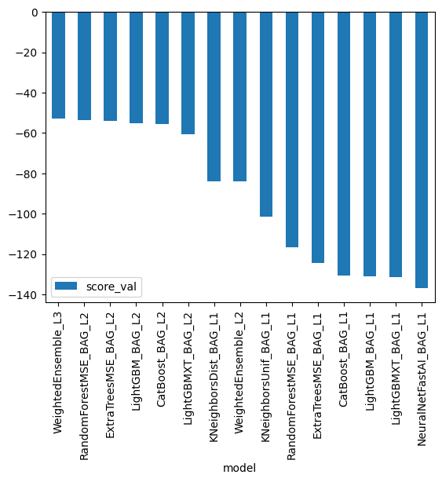

```python
predictor.leaderboard(silent=True).plot(kind="bar", x="model", y="score_val")
```

### Create predictions from test dataset

```python
predictions = predictor.predict(test)
predictions.head()
```

```
0    23.159439
1    41.606014
2    45.217789
3    48.239559
4    50.859413
Name: count, dtype: float32
```

#### NOTE: Kaggle will reject the submission if we don't set everything to be > 0.

```python
# Describe the `predictions` series to see if there are any negative values
predictions.describe()
```

```
count    6493.000000
mean      100.825081
std        90.254646
min         2.991500
25%        20.847715
50%        62.761375
75%       168.839691
max       364.695648
Name: count, dtype: float64
```

```python
# How many negative values do we have?
predictions.lt(0).value_counts()
```

```
False    6493
Name: count, dtype: int64
```

```python
# Set them to zero
# predictions[predictions < 0] = 0
```

### Set predictions to submission dataframe, save, and submit

```python
submission["count"] = predictions
submission.to_csv("submission.csv", index=False)
```

```python
# !kaggle competitions submit -c bike-sharing-demand -f submission.csv -m "first raw submission"
```

#### View submission via the command line or in the web browser under the competition's page - `My Submissions`

```python
# !kaggle competitions submissions -c bike-sharing-demand | tail -n +1 | head -n 6
```

## Step 4: Exploratory Data Analysis and Creating an additional feature

- Any additional feature will do, but a great suggestion would be to separate out the datetime into hour, day, or month parts.

```
array([[<AxesSubplot: title={'center': 'datetime'}>,
        <AxesSubplot: title={'center': 'season'}>,
        <AxesSubplot: title={'center': 'holiday'}>],
       [<AxesSubplot: title={'center': 'workingday'}>,
        <AxesSubplot: title={'center': 'weather'}>,
        <AxesSubplot: title={'center': 'temp'}>],
       [<AxesSubplot: title={'center': 'atemp'}>,
        <AxesSubplot: title={'center': 'humidity'}>,
        <AxesSubplot: title={'center': 'windspeed'}>],
       [<AxesSubplot: title={'center': 'count'}>, <AxesSubplot: >,
        <AxesSubplot: >]], dtype=object)
```

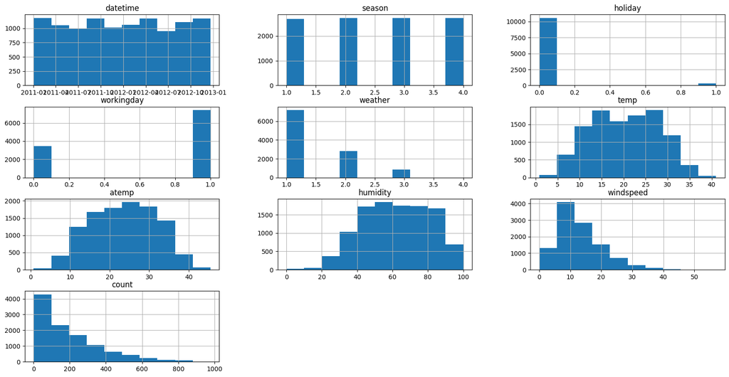

```python
# Create a histogram of all features to show the distribution of each one relative to the data. This is part of the exploritory data analysis
%matplotlib inline
train_data.hist(figsize = (20, 10))
```

```
array([[<AxesSubplot: title={'center': 'datetime'}>,
        <AxesSubplot: title={'center': 'season'}>,
        <AxesSubplot: title={'center': 'holiday'}>],
       [<AxesSubplot: title={'center': 'workingday'}>,
        <AxesSubplot: title={'center': 'weather'}>,
        <AxesSubplot: title={'center': 'temp'}>],
       [<AxesSubplot: title={'center': 'atemp'}>,
        <AxesSubplot: title={'center': 'humidity'}>,
        <AxesSubplot: title={'center': 'windspeed'}>]], dtype=object)
```

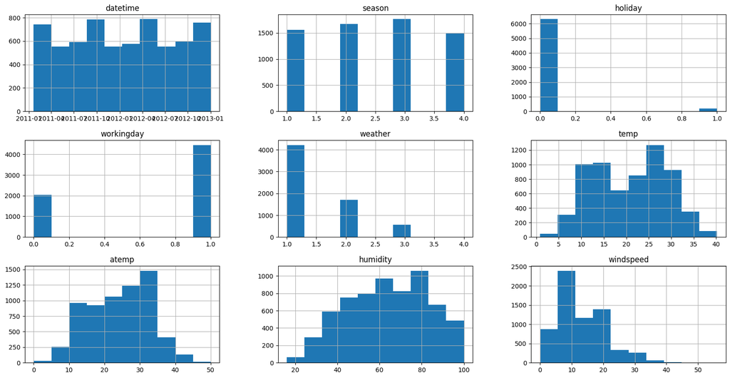

```python
# Create a histogram of all features to show the distribution of each one relative to the data. This is part of the exploritory data analysis
%matplotlib inline
test.hist(figsize = (20, 10))
```

```python
# create a new feature

train_data['year'] = train_data['datetime'].dt.year
train_data['month'] = train_data['datetime'].dt.month
train_data['day'] = train_data['datetime'].dt.day
train_data['hour'] = train_data['datetime'].dt.hour
test['year'] = test['datetime'].dt.year
test['month'] = test['datetime'].dt.month
test['day'] = test['datetime'].dt.day
test['hour'] = test['datetime'].dt.hour
```

## Make category types for these so models know they are not just numbers

- AutoGluon originally sees these as ints, but in reality they are int representations of a category.
- Setting the dtype to category will classify these as categories in AutoGluon.

```python
train_data["season"] = train_data["season"].astype("category")
train_data["weather"] = train_data["weather"].astype("category")
test["season"] = test["season"].astype("category")
test["weather"] = test["weather"].astype("category")

train_data = train_data.drop('datetime', axis = 1)
```

```python
test = test.drop('datetime', axis = 1)
```

```python
# View are new feature
train_data.head()
```

|  | season | holiday | workingday | weather | temp | atemp | humidity | windspeed | count | year | month | day | hour |
| --- | --- | --- | --- | --- | --- | --- | --- | --- | --- | --- | --- | --- | --- |
| 0 | 1 | 0 | 0 | 1 | 9.84 | 14.395 | 81 | 0.0 | 16 | 2011 | 1 | 1 | 0 |
| 1 | 1 | 0 | 0 | 1 | 9.02 | 13.635 | 80 | 0.0 | 40 | 2011 | 1 | 1 | 1 |
| 2 | 1 | 0 | 0 | 1 | 9.02 | 13.635 | 80 | 0.0 | 32 | 2011 | 1 | 1 | 2 |
| 3 | 1 | 0 | 0 | 1 | 9.84 | 14.395 | 75 | 0.0 | 13 | 2011 | 1 | 1 | 3 |
| 4 | 1 | 0 | 0 | 1 | 9.84 | 14.395 | 75 | 0.0 | 1 | 2011 | 1 | 1 | 4 |

```
array([[<AxesSubplot: title={'center': 'holiday'}>,
        <AxesSubplot: title={'center': 'workingday'}>,
        <AxesSubplot: title={'center': 'temp'}>],
       [<AxesSubplot: title={'center': 'atemp'}>,
        <AxesSubplot: title={'center': 'humidity'}>,
        <AxesSubplot: title={'center': 'windspeed'}>],
       [<AxesSubplot: title={'center': 'count'}>,
        <AxesSubplot: title={'center': 'year'}>,
        <AxesSubplot: title={'center': 'month'}>],
       [<AxesSubplot: title={'center': 'day'}>,
        <AxesSubplot: title={'center': 'hour'}>, <AxesSubplot: >]],
      dtype=object)
```

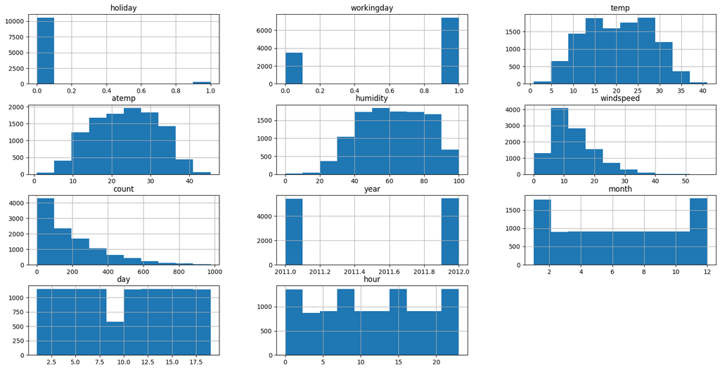

```python
# View histogram of all features again now with the hour feature
%matplotlib inline
train_data.hist(figsize = (20, 10))
```

```
array([[<AxesSubplot: title={'center': 'holiday'}>,
        <AxesSubplot: title={'center': 'workingday'}>,
        <AxesSubplot: title={'center': 'temp'}>],
       [<AxesSubplot: title={'center': 'atemp'}>,
        <AxesSubplot: title={'center': 'humidity'}>,
        <AxesSubplot: title={'center': 'windspeed'}>],
       [<AxesSubplot: title={'center': 'year'}>,
        <AxesSubplot: title={'center': 'month'}>,
        <AxesSubplot: title={'center': 'day'}>],
       [<AxesSubplot: title={'center': 'hour'}>, <AxesSubplot: >,
        <AxesSubplot: >]], dtype=object)
```

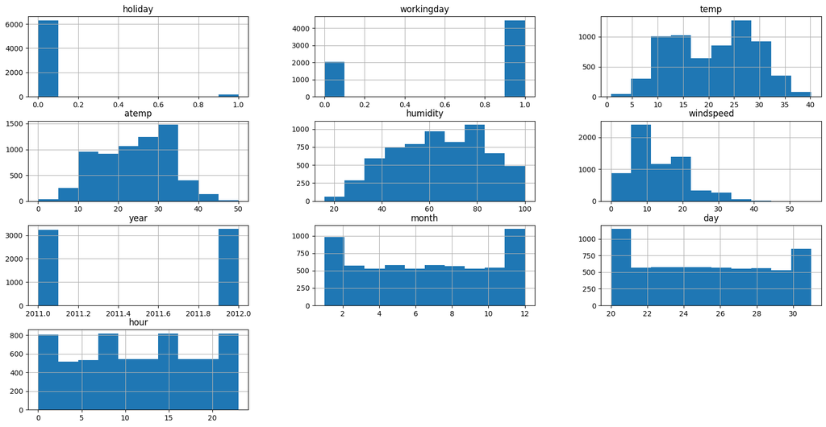

```python
%matplotlib inline
test.hist(figsize = (20, 10))
```

## Step 5: Rerun the model with the same settings as before, just with more features

```python
predictor_new_features = TabularPredictor(label="count",
                                            problem_type="regression",
                                            eval_metric="root_mean_squared_error").fit(
                                                    train_data = train_data,
                                                    time_limit = 600,
                                                    presets = 'best_quality')
```

```
No path specified. Models will be saved in: "AutogluonModels/ag-20221218_184724/"
Presets specified: ['best_quality']
Stack configuration (auto_stack=True): num_stack_levels=1, num_bag_folds=8, num_bag_sets=20
Beginning AutoGluon training ... Time limit = 600s
AutoGluon will save models to "AutogluonModels/ag-20221218_184724/"
AutoGluon Version:  0.6.1
Python Version:     3.8.12
Operating System:   Linux
Platform Machine:   x86_64
Platform Version:   #1 SMP Wed Oct 26 20:36:53 UTC 2022
Train Data Rows:    10886
Train Data Columns: 12
Label Column: count
Preprocessing data ...
Using Feature Generators to preprocess the data ...
Fitting AutoMLPipelineFeatureGenerator...
	Available Memory:                    1553.28 MB
	Train Data (Original)  Memory Usage: 0.89 MB (0.1% of available memory)
	Inferring data type of each feature based on column values. Set feature_metadata_in to manually specify special dtypes of the features.
	Stage 1 Generators:
		Fitting AsTypeFeatureGenerator...
			Note: Converting 3 features to boolean dtype as they only contain 2 unique values.
	Stage 2 Generators:
		Fitting FillNaFeatureGenerator...
	Stage 3 Generators:
		Fitting IdentityFeatureGenerator...
		Fitting CategoryFeatureGenerator...
			Fitting CategoryMemoryMinimizeFeatureGenerator...
	Stage 4 Generators:
		Fitting DropUniqueFeatureGenerator...
	Types of features in original data (raw dtype, special dtypes):
		('category', []) : 2 | ['season', 'weather']
		('float', [])    : 3 | ['temp', 'atemp', 'windspeed']
		('int', [])      : 7 | ['holiday', 'workingday', 'humidity', 'year', 'month', ...]
	Types of features in processed data (raw dtype, special dtypes):
		('category', [])  : 2 | ['season', 'weather']
		('float', [])     : 3 | ['temp', 'atemp', 'windspeed']
		('int', [])       : 4 | ['humidity', 'month', 'day', 'hour']
		('int', ['bool']) : 3 | ['holiday', 'workingday', 'year']
	0.1s = Fit runtime
```

[output cut: 70 more lines]

```
	-36.009	 = Validation score   (-root_mean_squared_error)
	8.05s	 = Training   runtime
	0.57s	 = Validation runtime
Fitting model: NeuralNetFastAI_BAG_L2 ... Training model for up to 39.53s of the 39.51s of remaining time.
	Fitting 8 child models (S1F1 - S1F8) | Fitting with ParallelLocalFoldFittingStrategy
	-36.4065	 = Validation score   (-root_mean_squared_error)
	50.47s	 = Training   runtime
	0.44s	 = Validation runtime
Completed 1/20 k-fold bagging repeats ...
Fitting model: WeightedEnsemble_L3 ... Training model for up to 360.0s of the -14.44s of remaining time.
	-35.7487	 = Validation score   (-root_mean_squared_error)
	0.5s	 = Training   runtime
	0.0s	 = Validation runtime
AutoGluon training complete, total runtime = 615.15s ... Best model: "WeightedEnsemble_L3"
TabularPredictor saved. To load, use: predictor = TabularPredictor.load("AutogluonModels/ag-20221218_184724/")
```

```python
predictor_new_features.fit_summary()
```

```
*** Summary of fit() ***
Estimated performance of each model:
                     model   score_val  pred_time_val    fit_time  pred_time_val_marginal  fit_time_marginal  stack_level  can_infer  fit_order
0      WeightedEnsemble_L3  -35.748748      24.228140  542.808823                0.001225           0.502930            3       True         16
1      WeightedEnsemble_L2  -35.890166      21.119421  345.274666                0.001089           0.520862            2       True          9
2     ExtraTreesMSE_BAG_L2  -36.009009      23.017087  396.072583                0.567254           8.049586            2       True         14
3          LightGBM_BAG_L2  -36.250187      22.556652  407.949936                0.106819          19.926939            2       True         11
4          CatBoost_BAG_L2  -36.281538      22.526550  437.229844                0.076717          49.206847            2       True         13
5   NeuralNetFastAI_BAG_L2  -36.406498      22.893049  438.495869                0.443216          50.472872            2       True         15
6   RandomForestMSE_BAG_L2  -36.623239      23.032909  414.649649                0.583076          26.626652            2       True         12
7        LightGBMXT_BAG_L2  -36.945231      22.780975  409.271839                0.331142          21.248842            2       True         10
8        LightGBMXT_BAG_L1  -37.097828      16.320429   90.687278               16.320429          90.687278            1       True          3
9          LightGBM_BAG_L1  -37.692850       4.101173   43.000051                4.101173          43.000051            1       True          4
10         CatBoost_BAG_L1  -38.233642       0.151324  201.919576                0.151324         201.919576            1       True          6
11    ExtraTreesMSE_BAG_L1  -41.612697       0.581672    4.925891                0.581672           4.925891            1       True          7
12  RandomForestMSE_BAG_L1  -42.150601       0.545407    9.146898                0.545407           9.146898            1       True          5
13  NeuralNetFastAI_BAG_L1  -99.365334       0.432263   38.271644                0.432263          38.271644            1       True          8
14   KNeighborsDist_BAG_L1 -119.365601       0.154614    0.034474                0.154614           0.034474            1       True          2
15   KNeighborsUnif_BAG_L1 -123.933260       0.162952    0.037184                0.162952           0.037184            1       True          1
Number of models trained: 16
Types of models trained:
{'StackerEnsembleModel_XT', 'StackerEnsembleModel_KNN', 'StackerEnsembleModel_RF', 'WeightedEnsembleModel', 'StackerEnsembleModel_LGB', 'StackerEnsembleModel_CatBoost', 'StackerEnsembleModel_NNFastAiTabular'}
Bagging used: True  (with 8 folds)
Multi-layer stack-ensembling used: True  (with 3 levels)
Feature Metadata (Processed):
(raw dtype, special dtypes):
('category', [])  : 2 | ['season', 'weather']
('float', [])     : 3 | ['temp', 'atemp', 'windspeed']
('int', [])       : 4 | ['humidity', 'month', 'day', 'hour']
('int', ['bool']) : 3 | ['holiday', 'workingday', 'year']
*** End of fit() summary ***
```

[output not shown]

[output cut: 151 more lines]

[output not shown]

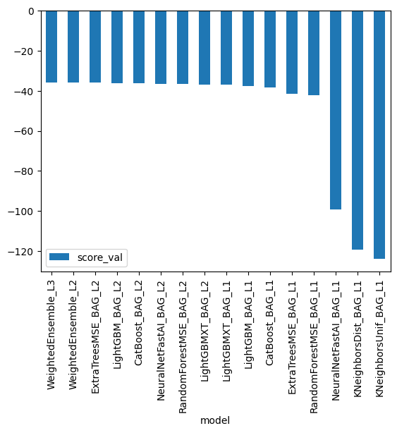

```python
predictor_new_features.leaderboard(silent=True).plot(kind="bar", x="model", y="score_val")
```

```python
new_predictions = predictor_new_features.predict(test)
```

```python
new_predictions.head()
```

```
0    14.021000
1     5.393598
2     4.464583
3     4.439572
4     4.344634
Name: count, dtype: float32
```

```python
new_predictions.describe()
```

```
count    6493.000000
mean      189.208496
std       172.706711
min         1.772315
25%        46.447426
50%       146.404495
75%       280.291168
max       887.815247
Name: count, dtype: float64
```

```python
new_predictions.lt(0).value_counts()
```

```
False    6493
Name: count, dtype: int64
```

```python
# Remember to set all negative values to zero
```

```python
# Same submitting predictions
submission_new_features = submission
submission_new_features["count"] = new_predictions
submission_new_features.to_csv("submission_new_features.csv", index=False)
```

```python
# !kaggle competitions submit -c bike-sharing-demand -f submission_new_features.csv -m "new features"
```

[output not shown]

```python
# !kaggle competitions submissions -c bike-sharing-demand | tail -n +1 | head -n 6
```

#### New Score of Score: 0.47023

## Step 6: Hyper parameter optimization

- There are many options for hyper parameter optimization.
- Options are to change the AutoGluon higher level parameters or the individual model hyperparameters.
- The hyperparameters of the models themselves that are in AutoGluon. Those need the `hyperparameter` and `hyperparameter_tune_kwargs` arguments.

```python
predictor_new_hpo = TabularPredictor(label="count",
                                     problem_type="regression",
                                     eval_metric="root_mean_squared_error").fit(
                                                            train_data = train_data,
                                                            auto_stack = True,
                                                            num_bag_folds = 5,
                                                            num_bag_sets = 10,
                                                            time_limit = 600,
                                                            presets = 'best_quality')
```

```
No path specified. Models will be saved in: "AutogluonModels/ag-20221218_190940/"
Presets specified: ['best_quality']
Stack configuration (auto_stack=True): num_stack_levels=1, num_bag_folds=5, num_bag_sets=10
Beginning AutoGluon training ... Time limit = 600s
AutoGluon will save models to "AutogluonModels/ag-20221218_190940/"
AutoGluon Version:  0.6.1
Python Version:     3.8.12
Operating System:   Linux
Platform Machine:   x86_64
Platform Version:   #1 SMP Wed Oct 26 20:36:53 UTC 2022
Train Data Rows:    10886
Train Data Columns: 12
Label Column: count
Preprocessing data ...
Using Feature Generators to preprocess the data ...
Fitting AutoMLPipelineFeatureGenerator...
	Available Memory:                    1936.42 MB
	Train Data (Original)  Memory Usage: 0.89 MB (0.0% of available memory)
	Inferring data type of each feature based on column values. Set feature_metadata_in to manually specify special dtypes of the features.
	Stage 1 Generators:
		Fitting AsTypeFeatureGenerator...
			Note: Converting 3 features to boolean dtype as they only contain 2 unique values.
	Stage 2 Generators:
		Fitting FillNaFeatureGenerator...
	Stage 3 Generators:
		Fitting IdentityFeatureGenerator...
		Fitting CategoryFeatureGenerator...
			Fitting CategoryMemoryMinimizeFeatureGenerator...
	Stage 4 Generators:
		Fitting DropUniqueFeatureGenerator...
	Types of features in original data (raw dtype, special dtypes):
		('category', []) : 2 | ['season', 'weather']
		('float', [])    : 3 | ['temp', 'atemp', 'windspeed']
		('int', [])      : 7 | ['holiday', 'workingday', 'humidity', 'year', 'month', ...]
	Types of features in processed data (raw dtype, special dtypes):
		('category', [])  : 2 | ['season', 'weather']
		('float', [])     : 3 | ['temp', 'atemp', 'windspeed']
		('int', [])       : 4 | ['humidity', 'month', 'day', 'hour']
		('int', ['bool']) : 3 | ['holiday', 'workingday', 'year']
	0.1s = Fit runtime
```

[output cut: 80 more lines]

```
	Fitting 5 child models (S1F1 - S1F5) | Fitting with ParallelLocalFoldFittingStrategy
	-37.1197	 = Validation score   (-root_mean_squared_error)
	15.42s	 = Training   runtime
	0.12s	 = Validation runtime
Fitting model: NeuralNetTorch_BAG_L2 ... Training model for up to 3.44s of the 3.43s of remaining time.
	Fitting 5 child models (S1F1 - S1F5) | Fitting with ParallelLocalFoldFittingStrategy
	Time limit exceeded... Skipping NeuralNetTorch_BAG_L2.
Completed 1/10 k-fold bagging repeats ...
Fitting model: WeightedEnsemble_L3 ... Training model for up to 360.0s of the -1.32s of remaining time.
2022-12-18 19:19:41,735	ERROR worker.py:399 -- Unhandled error (suppress with 'RAY_IGNORE_UNHANDLED_ERRORS=1'): The worker died unexpectedly while executing this task. Check python-core-worker-*.log files for more information.
	-36.0795	 = Validation score   (-root_mean_squared_error)
	0.68s	 = Training   runtime
	0.0s	 = Validation runtime
AutoGluon training complete, total runtime = 602.22s ... Best model: "WeightedEnsemble_L3"
TabularPredictor saved. To load, use: predictor = TabularPredictor.load("AutogluonModels/ag-20221218_190940/")
```

```python
predictor_new_hpo.fit_summary()
```

```
*** Summary of fit() ***
Estimated performance of each model:
                     model   score_val  pred_time_val    fit_time  pred_time_val_marginal  fit_time_marginal  stack_level  can_infer  fit_order
0      WeightedEnsemble_L3  -36.079469      20.695202  534.944642                0.001286           0.680976            3       True         17
1      WeightedEnsemble_L2  -36.257552      18.264019  338.003594                0.000806           0.441463            2       True          9
2     ExtraTreesMSE_BAG_L2  -36.398208      19.474508  387.973277                0.583970           8.078460            2       True         14
3          CatBoost_BAG_L2  -36.478886      18.933427  410.465475                0.042889          30.570658            2       True         13
4          LightGBM_BAG_L2  -36.700684      18.976087  391.796017                0.085549          11.901200            2       True         11
5   NeuralNetFastAI_BAG_L2  -36.757015      19.271194  441.477370                0.380656          61.582553            2       True         15
6   RandomForestMSE_BAG_L2  -37.003252      19.483115  406.715273                0.592577          26.820456            2       True         12
7           XGBoost_BAG_L2  -37.119720      19.008275  395.310338                0.117737          15.415522            2       True         16
8        LightGBMXT_BAG_L2  -37.251115      19.193211  392.695861                0.302673          12.801044            2       True         10
9        LightGBMXT_BAG_L1  -37.902659      13.964806   53.041870               13.964806          53.041870            1       True          3
10         CatBoost_BAG_L1  -37.994099       0.192527  247.159126                0.192527         247.159126            1       True          6
11         LightGBM_BAG_L1  -38.062122       3.055179   23.440753                3.055179          23.440753            1       True          4
12    ExtraTreesMSE_BAG_L1  -41.612697       0.514615    4.838097                0.514615           4.838097            1       True          7
13  RandomForestMSE_BAG_L1  -42.150601       0.536085    9.082285                0.536085           9.082285            1       True          5
14  NeuralNetFastAI_BAG_L1  -60.740151       0.360412   42.281394                0.360412          42.281394            1       True          8
15   KNeighborsDist_BAG_L1 -119.365601       0.134233    0.024204                0.134233           0.024204            1       True          2
16   KNeighborsUnif_BAG_L1 -123.933260       0.132680    0.027088                0.132680           0.027088            1       True          1
Number of models trained: 17
Types of models trained:
{'StackerEnsembleModel_XGBoost', 'StackerEnsembleModel_XT', 'StackerEnsembleModel_KNN', 'StackerEnsembleModel_RF', 'WeightedEnsembleModel', 'StackerEnsembleModel_LGB', 'StackerEnsembleModel_CatBoost', 'StackerEnsembleModel_NNFastAiTabular'}
Bagging used: True  (with 5 folds)
Multi-layer stack-ensembling used: True  (with 3 levels)
Feature Metadata (Processed):
(raw dtype, special dtypes):
('category', [])  : 2 | ['season', 'weather']
('float', [])     : 3 | ['temp', 'atemp', 'windspeed']
('int', [])       : 4 | ['humidity', 'month', 'day', 'hour']
('int', ['bool']) : 3 | ['holiday', 'workingday', 'year']
*** End of fit() summary ***
```

[output not shown]

[output cut: 163 more lines]

[output not shown]

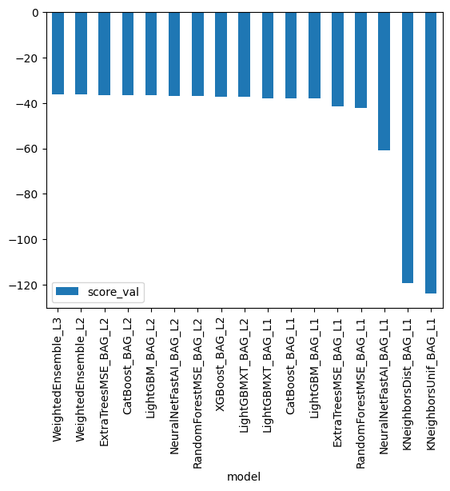

```python
predictor_new_hpo.leaderboard(silent=True).plot(kind="bar", x="model", y="score_val")
```

```python
hp_predictions = predictor_new_hpo.predict(test)
```

```python
hp_predictions.head()
```

```
0    13.576413
1     5.539682
2     4.595631
3     4.609892
4     4.624002
Name: count, dtype: float32
```

```python
hp_predictions.describe()
```

```
count    6493.000000
mean      189.266251
std       173.344345
min         0.894383
25%        46.423965
50%       145.867355
75%       281.455353
max       888.416687
Name: count, dtype: float64
```

```python
hp_predictions.lt(0).value_counts()
```

```
False    6493
Name: count, dtype: int64
```

```python
# Remember to set all negative values to zero
```

```python
# Same submitting predictions
submission_new_hpo = submission
submission_new_hpo["count"] = hp_predictions
submission_new_hpo.to_csv("submission_new_hpo.csv", index=False)
```

```python
# !kaggle competitions submit -c bike-sharing-demand -f submission_new_hpo.csv -m "new features with hyperparameters"
```

[output not shown]

```python
# !kaggle competitions submissions -c bike-sharing-demand | tail -n +1 | head -n 6
```

#### New Score of Score: 0.46574

```python
xgb_options = {'seed': 20,
                'max_depth': 6,
                 'n_estimators': 1000
              }

cat_options = {'iterations': 500,
               'depth': 10
              }

rf_options = {'max_depth': 6,
              'max_features': 'sqrt'
             }


hp = {'XGB': xgb_options, 'CAT': cat_options, 'RF': rf_options}

predictor_new_hpo_select = TabularPredictor(label="count",
                                     problem_type="regression",
                                     eval_metric="root_mean_squared_error").fit(
                                                            train_data = train_data,
                                                            auto_stack = True,
                                                            time_limit = 600,
                                                            hyperparameters = hp,
                                                            presets = 'best_quality')
```

```
No path specified. Models will be saved in: "AutogluonModels/ag-20221218_200051/"
Presets specified: ['best_quality']
Stack configuration (auto_stack=True): num_stack_levels=1, num_bag_folds=8, num_bag_sets=20
Beginning AutoGluon training ... Time limit = 600s
AutoGluon will save models to "AutogluonModels/ag-20221218_200051/"
AutoGluon Version:  0.6.1
Python Version:     3.8.12
Operating System:   Linux
Platform Machine:   x86_64
Platform Version:   #1 SMP Wed Oct 26 20:36:53 UTC 2022
Train Data Rows:    10886
Train Data Columns: 12
Label Column: count
Preprocessing data ...
Using Feature Generators to preprocess the data ...
Fitting AutoMLPipelineFeatureGenerator...
	Available Memory:                    1674.75 MB
	Train Data (Original)  Memory Usage: 0.89 MB (0.1% of available memory)
	Inferring data type of each feature based on column values. Set feature_metadata_in to manually specify special dtypes of the features.
	Stage 1 Generators:
		Fitting AsTypeFeatureGenerator...
			Note: Converting 3 features to boolean dtype as they only contain 2 unique values.
	Stage 2 Generators:
		Fitting FillNaFeatureGenerator...
	Stage 3 Generators:
		Fitting IdentityFeatureGenerator...
		Fitting CategoryFeatureGenerator...
			Fitting CategoryMemoryMinimizeFeatureGenerator...
	Stage 4 Generators:
		Fitting DropUniqueFeatureGenerator...
	Types of features in original data (raw dtype, special dtypes):
		('category', []) : 2 | ['season', 'weather']
		('float', [])    : 3 | ['temp', 'atemp', 'windspeed']
		('int', [])      : 7 | ['holiday', 'workingday', 'humidity', 'year', 'month', ...]
	Types of features in processed data (raw dtype, special dtypes):
		('category', [])  : 2 | ['season', 'weather']
		('float', [])     : 3 | ['temp', 'atemp', 'windspeed']
		('int', [])       : 4 | ['humidity', 'month', 'day', 'hour']
		('int', ['bool']) : 3 | ['holiday', 'workingday', 'year']
	0.1s = Fit runtime
```

[output cut: 144 more lines]

```
Repeating k-fold bagging: 13/20
Repeating k-fold bagging: 14/20
Repeating k-fold bagging: 15/20
Repeating k-fold bagging: 16/20
Repeating k-fold bagging: 17/20
Repeating k-fold bagging: 18/20
Repeating k-fold bagging: 19/20
Repeating k-fold bagging: 20/20
Completed 20/20 k-fold bagging repeats ...
Fitting model: WeightedEnsemble_L3 ... Training model for up to 360.0s of the 350.55s of remaining time.
	-96.1773	 = Validation score   (-root_mean_squared_error)
	0.0s	 = Training   runtime
	0.0s	 = Validation runtime
AutoGluon training complete, total runtime = 249.66s ... Best model: "WeightedEnsemble_L3"
TabularPredictor saved. To load, use: predictor = TabularPredictor.load("AutogluonModels/ag-20221218_200051/")
```

```python
predictor_new_hpo_select.fit_summary()
```

```
*** Summary of fit() ***
Estimated performance of each model:
                 model   score_val  pred_time_val   fit_time  pred_time_val_marginal  fit_time_marginal  stack_level  can_infer  fit_order
0      CatBoost_BAG_L1  -37.930820       0.093476  91.719937                0.093476          91.719937            1       True          2
1      CatBoost_BAG_L2  -38.652219       0.516778  80.175381                0.125048          78.786964            2       True          6
2       XGBoost_BAG_L1  -39.288846       1.140737  27.910649                1.140737          27.910649            1       True          3
3       XGBoost_BAG_L2  -40.007325       1.190642  29.891051                0.798912          28.502635            2       True          7
4  RandomForest_BAG_L2  -96.177263       0.773665   2.898651                0.381934           1.510234            2       True          5
5  WeightedEnsemble_L3  -96.177263       0.774434   2.903498                0.000769           0.004847            3       True          8
6  RandomForest_BAG_L1 -109.511470       0.391730   1.388417                0.391730           1.388417            1       True          1
7  WeightedEnsemble_L2 -109.511470       0.392856   1.394086                0.001126           0.005670            2       True          4
Number of models trained: 8
Types of models trained:
{'WeightedEnsembleModel', 'StackerEnsembleModel_CatBoost', 'StackerEnsembleModel_RF', 'StackerEnsembleModel_XGBoost'}
Bagging used: True  (with 8 folds)
Multi-layer stack-ensembling used: True  (with 3 levels)
Feature Metadata (Processed):
(raw dtype, special dtypes):
('category', [])  : 2 | ['season', 'weather']
('float', [])     : 3 | ['temp', 'atemp', 'windspeed']
('int', [])       : 4 | ['humidity', 'month', 'day', 'hour']
('int', ['bool']) : 3 | ['holiday', 'workingday', 'year']
*** End of fit() summary ***
```

[output not shown]

[output cut: 51 more lines]

[output not shown]

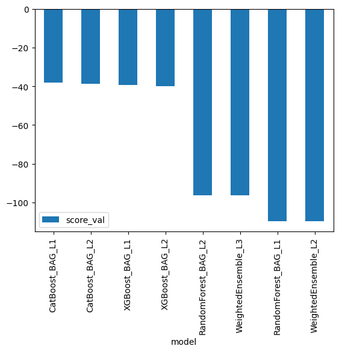

```python
predictor_new_hpo_select.leaderboard(silent=True).plot(kind="bar", x="model", y="score_val")
```

```python
select_hpo_predictions = predictor_new_hpo_select.predict(test)
```

```python
select_hpo_predictions.describe()
```

```
count    6493.000000
mean      191.397964
std       134.282593
min        16.326283
25%        66.370659
50%       184.231720
75%       300.499298
max       565.868713
Name: count, dtype: float64
```

```python
# Same submitting predictions
submission_new_hpo_select = submission
submission_new_hpo["count"] = select_hpo_predictions
submission_new_hpo.to_csv("submission_new_hpo_select.csv", index=False)
```